# Rockfish Historical Harvest Estimates

Phil Joy & Adam Reimer

December 2024

## Summary

This project seeks to improve on the Howard et al. (2020) methods used to estimate sport fish harvest, catches and releases of rockfish in Alaska waters. This is essentially a Bayesian version of the Howard methods that allows for more appropriate and defensible sharing of information between areas, handles missing data in a more appropriate manor, accurately propagates uncertainty throughout the estimation procedure and thus does not rely on the decision tree approach in the original Howard methods. Furthermore, the Bayesian approach should provide sport fish harvest, catch and mortality estimates back to 1978 when the SWHS was implemented. Harvest estimates should be mostly consistent with Howard estimates during contemporary times, but may differ based on more appropriate weighting of SWHS and logbook data, including estimating and correcting bias in the SWHS data. Furthermore, the Howard methods are wholly reliant on logbook release estimates and ignore the release estimates from the SWHS data (inferred from the catch and harvest estimates). Here we explore several models that attempt to balance all of the data in estimating releases.

## Data

### Stateside Harvest Survey (SWHS)

Statewide harvest survey estimates of rockfish catch and harvest are available for 28 years (1996-2023) for all users and for 13 years (2011-2023) for guided anglers. Additionally, there are estimates from 1977- 1995 that required some partitioning work to ascribe to current management units. Harvests in unknown areas were apportioned based on harvest proportions in 1996. Variance estimates are not available for pre-1996 data and as such, the maximum observed coefficient of variation (cv) in each commercial fisheries management unit was applied.

SWHS estimates are believed to be biased to some degree. These modelling efforts aim to estimate and correct for that bias with the assumption that logbook harvests are a census of guided harvests.

Rockfish release estimates are inferred from the difference between catch and harvest estimates.

Adam noted that the first 5 years (23 years counting the historical data) in the SWHS data set for PWSO seem unreasonable (close to zero and not corroborated with logbook estimates). Adam recommended setting these harvests to unknown, but current model development has included the data. Once a satisfactory model has been identified we will exam the effects of censoring the PWSO data.

### Guide Logbooks

Sport fishing guides were required to report their harvest of rockfish for 26 years (1998-2023). Reported harvest is also available by assemblage (pelagic vs. non-pelagic). Harvest of yelloweye rockfish were reported separately beginning in 2006.

Logbooks also record the number of rockfish released for the same categories. However, the reliability of the release data is somewhat questionable as reported releases are generally far lower than that estimated by the SWHS. As such several treatments of the data are considered.

### Logbook versus SWHS estimates

Estimates of guided harvests and releases from the SWHS do not align with the census from charter logbooks. Logbook harvest reports are generally considered reliable and are used to assess the bias in SWHS reports. However, there is even greater disparity between release estimates in the two sources and it is debatable whether logbook releases should be treated as a census. The Howard et al. (2020) methods do treat the logbook release data as “true” and thus are considerably less than would be estimated from the SWHS data.

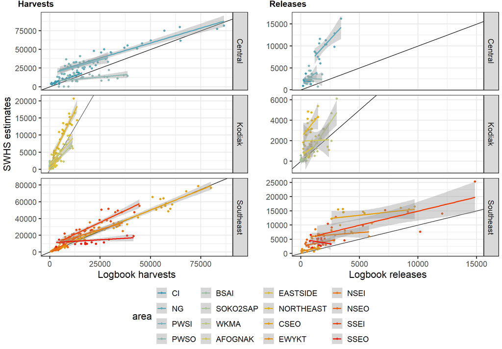

**Figure 1.**- SWHS harvest estimates from guided trips (Hhat) versus repoted harvests from charter logbooks (H_lb).

The Howard methods treat the logbook release data as a census and then use the ratio of guided:unguided releases in the SWHS to expand the logbook release estimates to generate total and unguided estimates. *NOTE: I am debating whether I need to rework the model to stay consistent with these methods?*

To evaluate this discrepancy, several models were used to estimate releases in this exploration. One method ($LB_{fit}$) considers the logbook release data to be reliable and a second method ($LB_{cens}$) treats the logbook release data as estimates of the minimum released, thus giving more weight to SWHS release estimates. A third method ($LB_{hyb}$) is a hybrid approach that treats reported releases of yelloweye as reliable but total rockfish and pelagic rockfish releases as minimums. Model development to date has revealed a tension between the total and pelagic logbook releases and the yelloweye logbook releases.

### Composition data

Harvest sampling data exists from Gulf of Alaska areas since 1993 and from Southeast Alaska areas since 2006. Port sampling data is comprised of the number of total rockfish, pelagic and non-pelagic rockfish, black rockfish and yelloweye rockfish.

A current challenge at this juncture is how to accommodate the prohibition on retaining yelloweye in Southeast from 2020 through 2024. Because it is closed to retention the port sampling data is not reflective of releases while remaining an accurate description of the harvest. Current modelling efforts revolve around developing a separate yelloweye curve that censors the missing data.

## Process equations

The true harvest $H_{ay}$ and catch $C_{ay}$ of rockfish for area $a$ during year $y$ is assumed to follow a temporal trend defined by a penalized spline:

$$\begin{equation}
\textrm{log}(H_{ay})~\sim~\textrm{Normal}(f(a,y), 0.25)
\end{equation}$$

where $f(a,y)$ in a p-spline basis with 5 components and a second degree penalty. A variance of 0.25 was assumed to allow substantial variability around the spline although current model development has explored using a normal or uniform prior on the variance. $C_{ay}$ is defined similarly.

Charter and private harvest $H_{ayu}$ and catch $C_{ayu}$ (where u = 1 for charter anglers and u=2 for private anglers) are a fraction of total annual harvest in each area:

$$\begin{equation}
H_{ay1}~=~H_{ay}P_{(user)ay1}\\H_{ay2}~=~H_{ay}(1-P_{(user)ay1})
\end{equation}$$

where $P_{H(user)ay1}$ is the fraction of the annual harvest and $P_{C(user)ay1}$ is the fraction of the annual catch in each area taken by charter anglers. $P_{(user)ay1}$ was modeled hierarchically across years as:

$$\begin{equation}
P_{H/C(user)ay1}~\sim~\textrm{beta}(\lambda1_a, \lambda2_a)
\end{equation}$$

with non-informative priors on both parameters.

Annual black rockfish harvest $H_{(black)ayu}$ and catch $C_{(black)ayu}$ for each area and user group is:

$$\begin{equation}
H_{(black)ayu}~=~H_{ayu}P_{(pelagic)ayu}P_{(black|pelagic)ayu}
\end{equation}$$

where $P_{(pelagic)ayu}$ is the fraction of the annual harvest and catch for each area and user group that was pelagic rockfish and $P_{(black|pelagic)ayu}$ is the fraction of the annual harvest and catch of pelagic rockfish for each area and user group that was black rockfish. Annual yelloweye rockfish harvest $H_{(yelloweye)ayu}$ and $C_{(yelloweye)ayu}$ for each area and user group:

$$\begin{equation}
H_{(yelloweye)ayu}~=~H_{ayu}(1-P_{(pelagic)ayu})P_{(yelloweye|non-pelagic)ayu}
\end{equation}$$

where $P_{(yellow|non-pelagic)ayu}$ is the fraction of the annual harvest and catch of non-pelagic rockfish for each area and user group that was yelloweye rockfish. Composition parameters ($P_{(pelagic)ayu}$, $P_{(black|pelagic)ayu}$, $P_{(yelloweye|non-pelagic)ayu}$) were modeled using a logistic curve that would allow hindcasting based on the oldest trend in the data without extrapolating beyond observed data values such that:

$$\begin{equation}
\textrm{logit}(P_{(comp)ayu})~=~\beta1_{(comp)ayu} +
\frac{\beta2_{(comp)ayu}}{(1 + exp(\beta3_{(comp)ayu}*(y -
\beta4_{(comp)ayu})))} + \beta5_{(comp)ayu}*I(u=private)+re_{(comp)ayu}
\end{equation}$$

where the $\beta$ parameters are define the intercept, scaling factor, steepness, inflection point and private angler effect, respectively, $y$ is the year index, $I(u=private)$ is an index variable which is 1 when the user groups is private and ) otherwise and $re_{(comp)ayu}$ is a random effect with a non-informative prior.

Releases by user group $R_{ayu}$ are estimated as the difference between estimated catch and harvest such that

$$\begin{equation}
R_{ayu}~=~C_{ayu}-H_{ayu}
\end{equation}$$

and is estimated similarly for each species grouping such that

$$\begin{equation}
R_{(pelagic)ayu}~=~C_{(pelagic)ayu}-H_{(pelagic)ayu}\\
R_{(black)ayu}~=~C_{(black)ayu}-H_{(black)ayu}\\
R_{(yelloweye)ayu}~=~C_{(yelloweye)ayu}-H_{(yelloweye)ayu}\\
\end{equation}$$

Total releases are summed across user groups.

Because SWHS catch estimates are not available for the entire time series a logistic curve is fit to the proportion harvest $pH_{ay}$ which provides an estimate off of which to hindcast catch and releases back through the entire time series. Thus

$$\begin{equation}
\textrm{logit}(pH_{ay})~=~\beta1_{(pH)ay} + \frac{\beta2_{(pH)ay}}{(1 +
exp(\beta3_{(pH)ay}*(y - \beta4_{(pH)ay})))}
\end{equation}$$

and the estimated catch $C_{ay}$ from 1977 - 1990 is estimated as

$$\begin{equation}
C_{ay}~=~H_{ay} / pH_{ay}
\end{equation}$$

## Observation equations

SWHS estimates of annual rockfish harvest $\widehat{SWHS}_H{ay}$ were assumed to index true harvest:

$$\begin{equation}
\widehat{SWHS}_H{ay}~\sim~\textrm{LogNormal}\left(\textrm{log}(H_{ay}b_{ay}),
\sigma_{SWHSHay}^2\right)
\end{equation}$$

where bias in the SWHS estimates $b_H{ay}$ is modeled hierarchically across years as:

$$\begin{equation}
b_H{ay}~\sim~\textrm{Normal}(\mu_{(b)a}, \sigma_{(b)a})
\end{equation}$$

with non-informative priors on both parameters. SWHS estimates of annual rockfish catches (harvests and releases) $\widehat{SWHS}_C{ay}$ were assumed to index true catches similarly. SWHS catch data is assumed to either have the same bias as the harvest data or is allowed to vary from $b_H{ay}$ based on an offset $Cboff_{a}$ that is modeled hierarchically across region *r* such that

$$\begin{equation}
b_C{ay}~=~b_H{ay} + Cboff_{ay}
\end{equation}$$

where

$$\begin{equation}
Cboff_{a}~\sim~\textrm{Normal}(\mu_{(bC)r}, \sigma_{(bC)r})
\end{equation}$$

Reported guide logbook harvest $\widehat{LB}_H{ay}$ is related to true harvest as:

$$\begin{equation}
\widehat{LB}_H{ay}~\sim~\textrm{Poisson}(H_{ay1})\\
\widehat{LB}_H{(pelagic)ay}~\sim~\textrm{Poisson}(H_{ay1}P_{(pelagic)ay1})\\
\widehat{LB}_H{(yelloweye)ay}~\sim~\textrm{Poisson}(H_{(yelloweye)ay1})\\
\end{equation}$$

Because logbook release data is more questionable several approaches have been explored. In the first approach model $LB_{fit}$ treats the release data as a true census and the releases are related to true releases similarly to the harvests:

$$\begin{equation}
\widehat{LB}_R{ay}~\sim~\textrm{Poisson}(R_{ay1})\\
\widehat{LB}_R{(pelagic)ay}~\sim~\textrm{Poisson}(R_{ay1}P_{(pelagic)ay1})\\
\widehat{LB}_R{(yelloweye)ay}~\sim~\textrm{Poisson}(R_{(yelloweye)ay1})\\
\end{equation}$$

In the second approach we consider the logbook release data to be a minimal estimate of the true releases. Thus model $LB_{cens}$ censors the release data (censored data is entered as NA) and treats the reported releases as a minimal number such that

$$\begin{equation}
\text{censored}
\widehat{LB}_R{ay}~\sim~\textrm{LogNormal}\left(\log(R_{ay}),
1\right)\text{T}\left(\widehat{LB}_R{ay}, \infty\right)\\
\text{censored}
\widehat{LB}_R{(pelagic)ay}~\sim~\textrm{LogNormal}\left(\log(R_{(pelagic)ay}),
1\right)\text{T}\left(\widehat{LB}_R{(pelagic)ay}, \infty\right)\\
\text{censored}
\widehat{LB}_R{(ye)ay}~\sim~\textrm{LogNormal}\left(\log(R_{(ye)ay}),
1\right)\text{T}\left(\widehat{LB}_R{(ye)ay}, \infty\right)\\
\end{equation}$$

Model $LB_{hyb}$ is a hybrid approach that treats the yelloweye releases as a reliable census of yelloweye releases (given the emphasis and ease of recording these fish) but censors the pelagic and total rockfish release estimates such that

$$\begin{equation}
\text{censored}
\widehat{LB}_R{ay}~\sim~\textrm{LogNormal}\left(\log(R_{ay}),
1\right)\text{T}\left(\widehat{LB}_R{ay}, \infty\right) \\
\text{censored}
\widehat{LB}_R{(pelagic)ay}~\sim~\textrm{LogNormal}\left(\log(R_{(pelagic)ay}),
1\right)\text{T}\left(\widehat{LB}_R{(pelagic)ay}, \infty\right) \\
\widehat{LB}_R{(yelloweye)ay}~\sim~\textrm{Poisson}(R_{(yelloweye)ay1})\\
\end{equation}$$

SWHS estimates of guided angler harvest $\widehat{SWHS}_H{ay1}$ are related to total harvest by:

$$\begin{equation}
\widehat{SWHS}_H{ay1}~\sim~\textrm{LogNormal}\left(\textrm{log}(H_{ay1}b_{ay}),
\sigma_{SWHS_{ay1}}^2\right)
\end{equation}$$

SWHS estimates of guided angler catch $\widehat{SWHS}_C{ay1}$ is modeled similarly.

The number of pelagic rockfish sampled in harvest sampling programs $x_{(pelagic)ayu}$ follow a binomial distribution:

$$\begin{equation}
x_{(pelagic)ayu}~\sim~\textrm{Binomial}(P_{(pelagic)ayu}, N_{ayu})
\end{equation}$$

where $N_{ayu}$ is the total number of rockfish sampled in area $a$ during year $y$ form user group $u$. The number of black rockfish sampled in harvest sampling programs and the number of yellow rockfish sampled modeled analogously with an appropriately substituted $N$.

### Unresolved issues and outstanding questions:

Before looking at results, here is a list of current issues that need to be resolved as well as a list of development steps that still need to be taken.

1. *Release estimation:* Although harvests estimates are mostly consistent with Howard etal methods, the new release estimation methods presented here are considerably different. It should be noted, however, that the scale of releases should not cause managers concern and not change our general understanding of fishing pressure on these stocks. Note that even when we fit to lb yelloweye release estimates the model still thinks there are a lot of unreported releases of rockfish and pelagic rockfish. I lean towards the hybrid model as a balancing of logbook data and swhs data. Additionally, the model struggles the most when all logbook releases are taken as a census.
2. *Fishery closures:* Retention of yelloweye has been prohibited in SE Alaska since 2020 and thus they are absent from port sampling. This means that pYE for releases is not estimable from the composition data. To deal with this I estimated a second pYE curve for releases that censors the port sampling data for years when the fishery is closed, and this allows the pYE curve to continue through the closed years based on where things were before the closure. I think this is working, but computationally it is a little redundant, although the second curve is only applied to SE data. The p_yelloweye curve looks good for the closed years in the $LB_{cens}$ model, but struggles in the $LB_{hyb}$ and $LB_{fit}$ models, even with the inflection point of the curve ($\beta4$ above/ $\beta3$ in model) truncated to keep it within the observed time period prior to the closure.
3. *Complete convergence* has not been achieved and spline parameters (in particular lambdas) are the main culprit. Feedback on prior choices would be helpful.
4. *Prior choices* in general need to be vetted. Ideally, sensitivity testing would occur but the model is very slow to converge.
5. *Random effects on pH:* Should I include random effects on pH? The model does not currently have them but it might be useful for considering variability in the pH line used to estimate catches in pre-catch data years.
6. *Model comparisons:* I need to write code for comparing models side by side as well as quantifying the differences between these methods and the Howard methods.

# Results

- **Model:** *LB_cens*
- **Model Run:** *model_HCR_censLBR_xYEv2_flexlambda2_thru2023_1200000_7kn_2024-12-04* (Naming convention: modelname_thruYEAR_iters_rundate)
- **Proportion of parmaters converged (Rhat <= 1.1):** 0.96
- *See end of document for summary of unconverged parameters.*

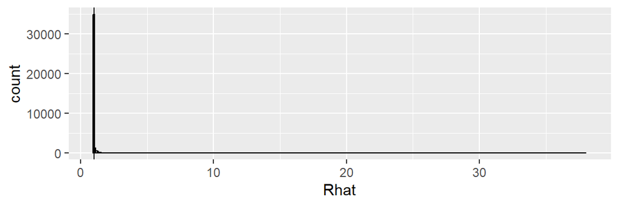

## Estimate comparison

Since previous estimates of rockfish harvest have been produced these first 3 graphs will be used to show how the modeled estimates compare to the estimates produced earlier. For total rockfish the estimates are in general agreement although differences are noted. These estimates should be more reliable because they include both SWHS and guide logbook data, handle variance more appropriately, use hierarchical distributions when data is missing, directly consider observation error and are produced using reproducible research.

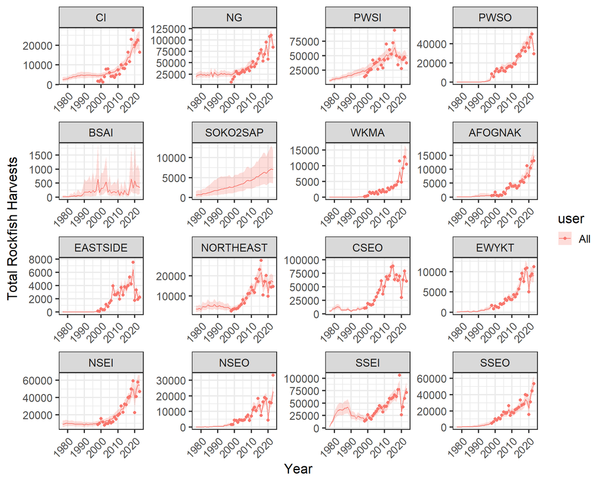

**Figure 2.**- Total rockfish harvests 1996–2023. Lines and error polygons represent model estimates and points and error bars represent Howard et al estimates.

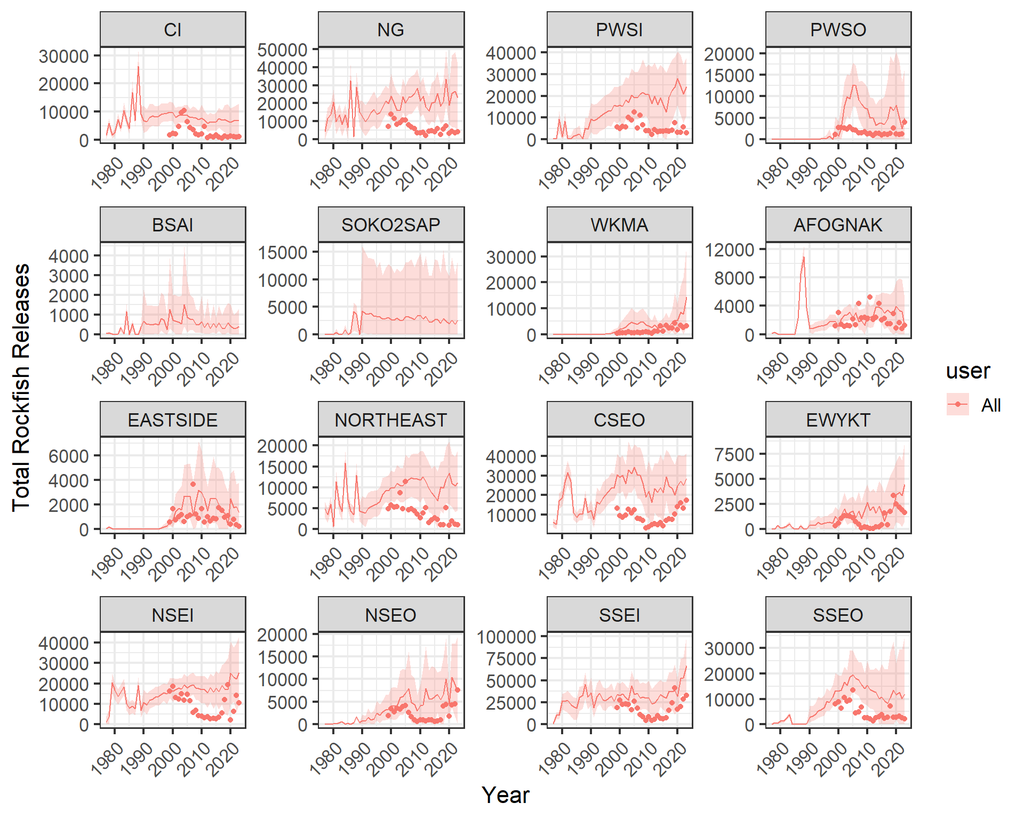

**Figure 3.**- Total rockfish releases 1996–2023. Lines and error polygons represent model estimates and points and error bars represent Howard et al estimates.

*Notes from Adam:* When looking at only black rockfish the most significant differences are for the Prince William Sound Inside area. I did not spend a great deal of time tracking this down although it looks like the previous version used bad values for $P_{(black)ayu}$ for at least unguided anglers. For the moment I would ignore the results for BSIA and SOKO2SAP. I think it is possible to give approximate values for these areas but it will require a little more coding which I have yet to do.

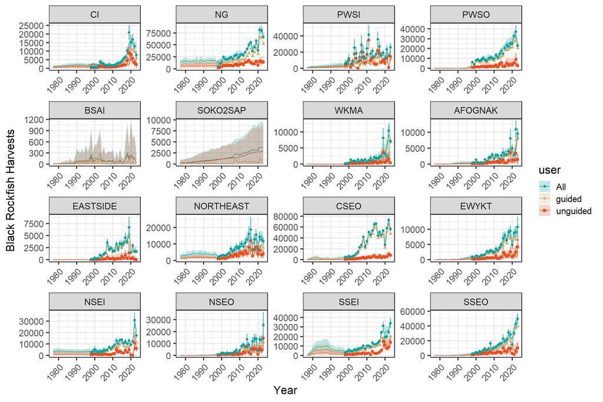

**Figure 4.**- Black rockfish harvests 1996–2023. Lines and error polygons represent model estimates and points and error bars represent Howard et al estimates.

And black rockfish releases…

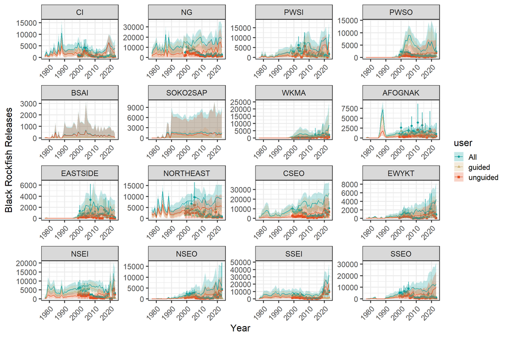

**Figure 5.**- Black rockfish releases 1996–2023. Lines and error polygons represent model estimates and points and error bars represent Howard et al estimates.

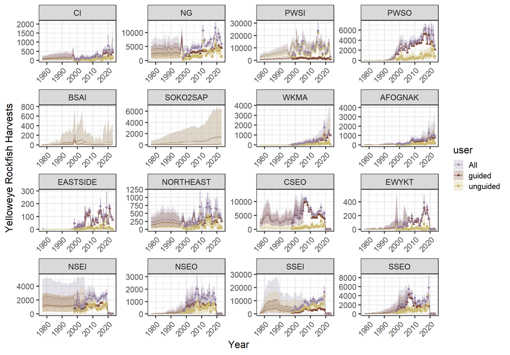

**Figure 6.**- Yellow rockfish harvests 1996–2023. Lines and error polygons represent model estimates and points and error bars represent Howard et al estimates.

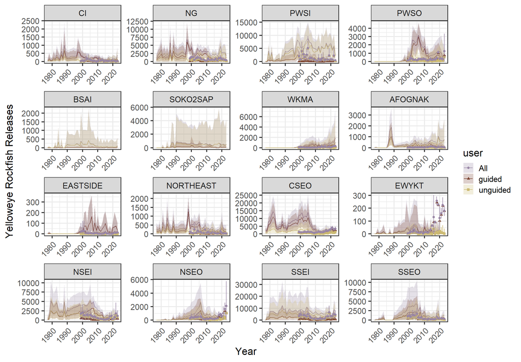

**Figure 7.**- Yellow rockfish releases 1996–2023. Lines and error polygons represent model estimates and points and error bars represent Howard et al estimates.

## Model fit

### Logbook residuals

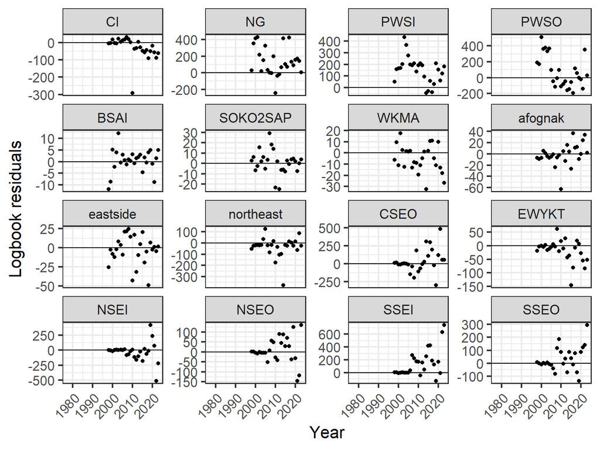

**Figure 8.**- Residuals from logbook harvests

### SWHS residuals

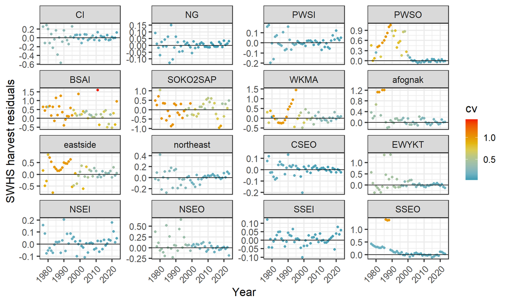

**Figure 9.**- Residuals from SWHS harvests.

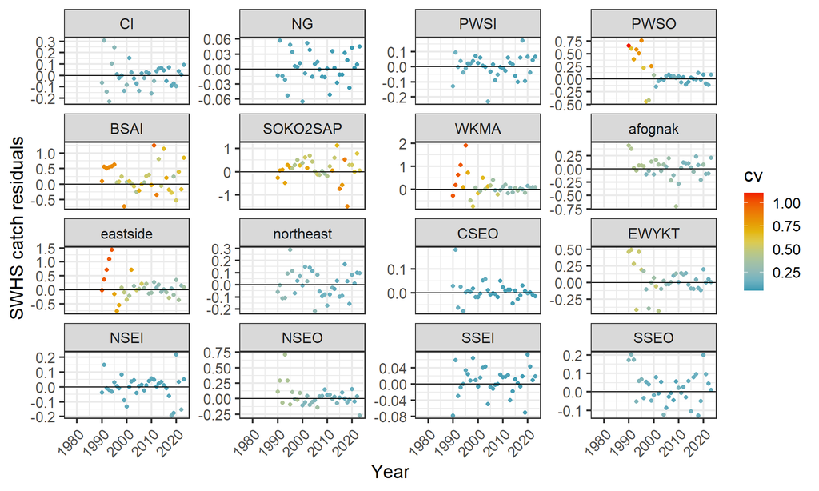

**Figure 10.**- Residual of SWHS catches

## Parameter estimates

### P(Charter)

These histograms show the posterior distribution of the mean percent of rockfish harvested by the charter fleet.

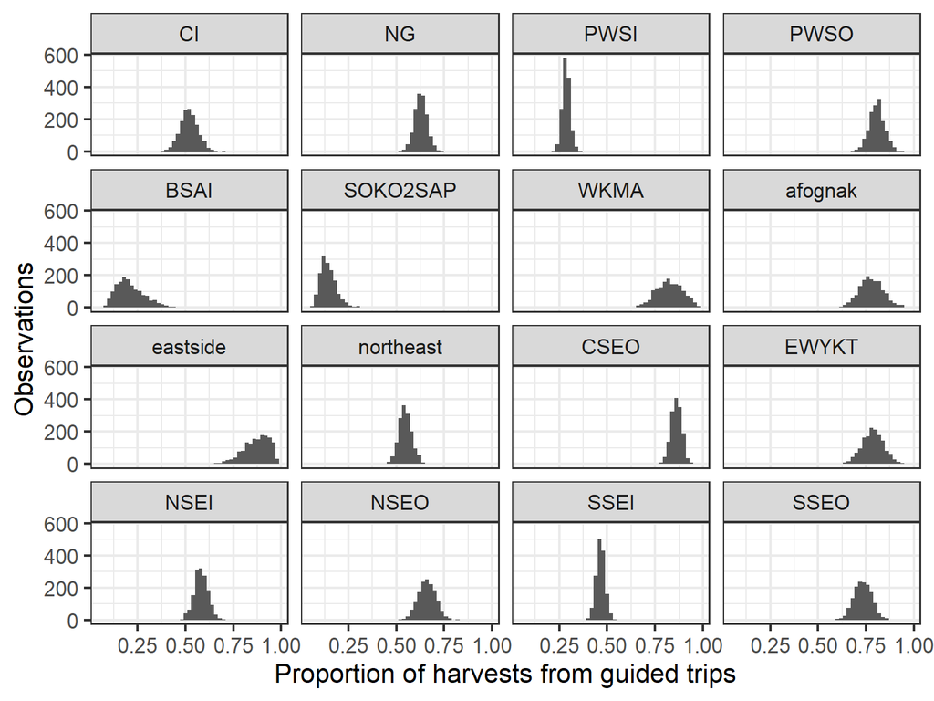

**Figure 11.**- Mean percent of harvest by charter anglers.

When considered annually we see the percent of rockfish harvested by the charter fleet follows our data fairly well although we just do not have much information about this ratio. Prior to 2011 the percent charter is confounded with SWHS bias and should be mostly discounted.

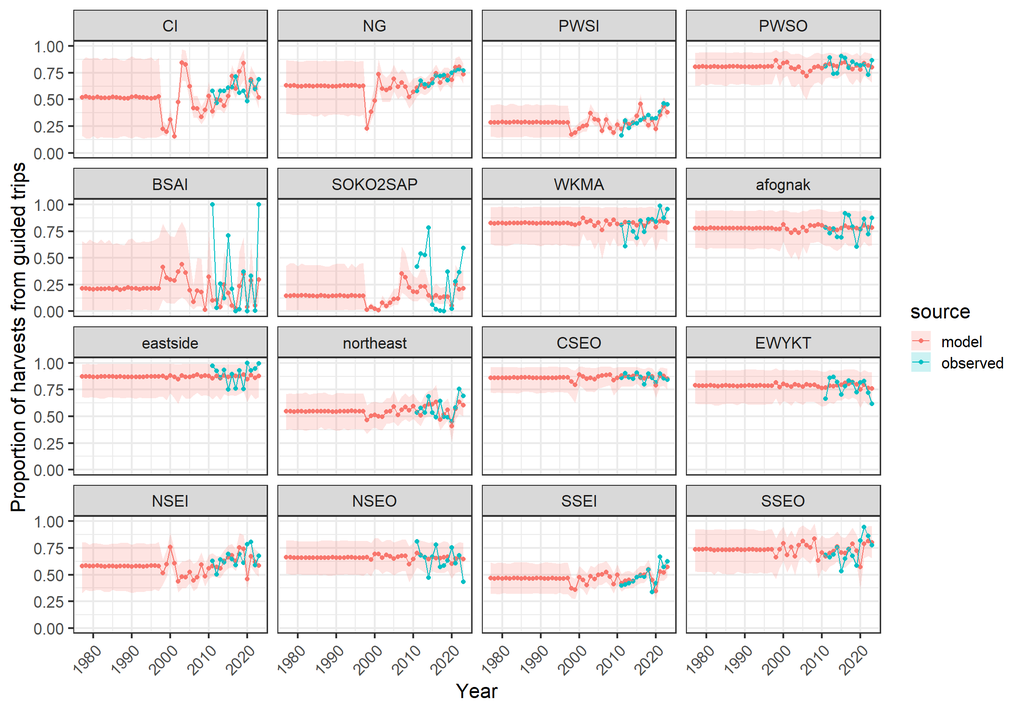

**Figure 12.**- Annual estimates of the percent of harvest by charter anglers for 16 commerical fishing manamgent areas, 1996-2023.

### P(Harvest)

These plots show the fitted logistic line to the proportion of caught rockfish that are harvested. These estimates are used for hindcasting catch estimates based on the harvest data in early years when catch estimates are unavailable.

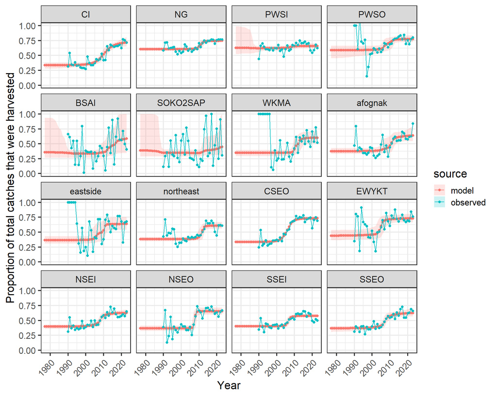

**Figure 13.**- Annual proportion of catch that was harvested. Note that pre-1990 estimates are used to estimate catch in these years when catch estimates are not available.

### SWHS bias

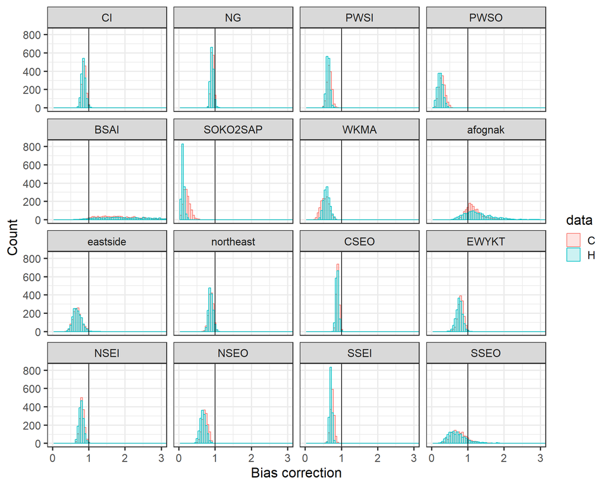

**Figure 14.**- Mean SWHS bias for harvests and catches.

Our estimates of SWHS bias track observations fairly well when he have guided harvest estimates. There are some disturbing trends/patterns seen in the earlier time periods. Often the patterns represent periods where SWHS estimates and guide logbook estimates do not follow the recent relationship. I’m not sure what drives the trends but it seems plausible to me that long-term changes in the ratio of charter and private anglers may be a factor. If Charter/Private ratio information is available in the historical creel data it my be helpful here (particularly for North Southeast Inside and South Southeast outside).

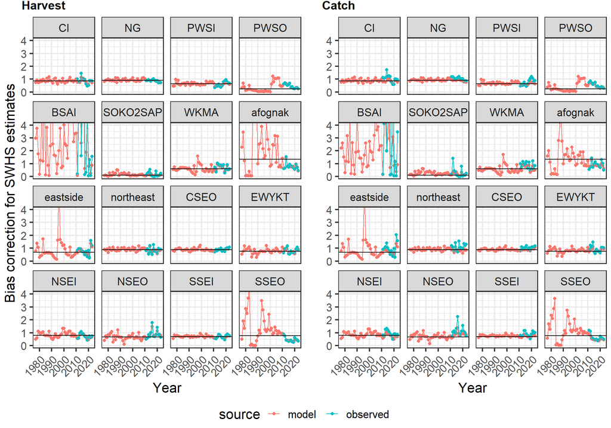

**Figure 15.**- Annual estimates of SWHS bias in harvests and catches for 16 commerical fishing manamgent areas, 1996-2023.

### P(pelagic)

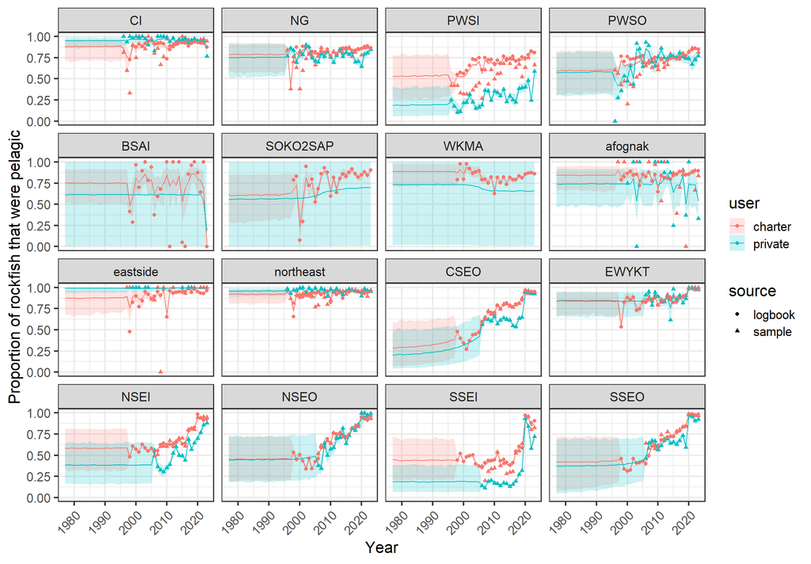

**Figure 16.**- Annual estimates of the percent of the sport harvest that was pelagic rockfish for 16 commerical fishing manamgent areas, 1996-2023.

### P(black|pelagic)

Note that in Southeast Alaska we only have composition data starting in 2006. Tania dug up old SE data, but it did not provide any useful data for species apportionment.

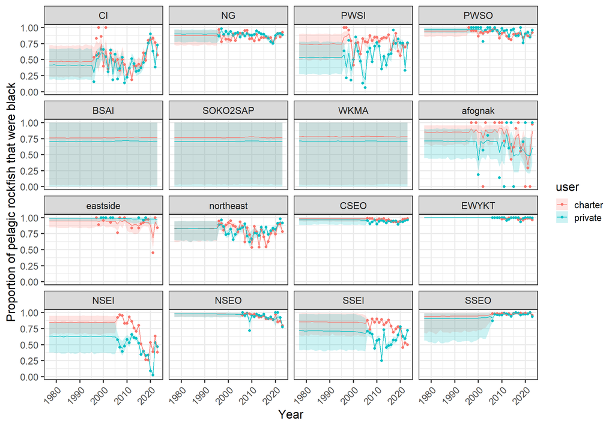

**Figure 17.**- Annual estimates of the percent of the sport harvest of pelagic rockfish that were black rockfish for 16 commerical fishing manamgent areas, 1996-2023.

### P(yelloweye|non-pelagic)

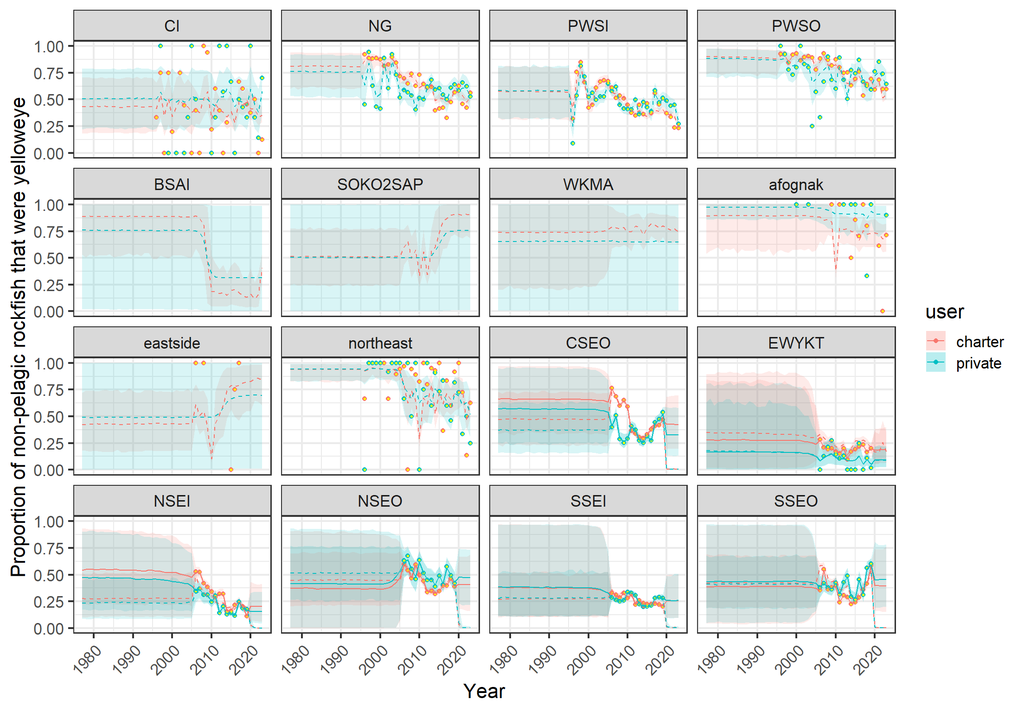

**Figure 18.**- Annual estimates of the percent of the sport harvest of non-pelagic rockfish that were yelloweye rockfish for 16 commerical fishing manamgent areas, 1996-2023.

### Summary of unconverged parameters:

**Table 1.** Summary of unconverged parameters including the number (n) and the average Rhat from the unconverged parameters.

| parameter | n | badRhat_avg |
| --- | --- | --- |
| beta_C | 47 | 2.906485 |
| mu_lambda_C | 1 | 1.387195 |
| beta2_yellow_x | 1 | 1.340532 |
| beta0_yellow_x | 2 | 1.297379 |
| beta3_yellow_x | 1 | 1.293026 |
| beta1_yellow_x | 1 | 1.245938 |
| tau_beta0_black | 3 | 1.228752 |

| parameter | n | badRhat_avg |
| --- | --- | --- |
| beta_H | 3 | 1.217532 |
| beta0_pelagic | 2 | 1.196830 |
| beta1_pelagic | 3 | 1.194524 |
| beta1_pH | 2 | 1.161964 |
| sd_bc_H | 1 | 1.133923 |
| sigma_lambda_C | 2 | 1.120043 |

**Table 2.** Summary of unconverged parameters by area

|  | CI | CSEO | eastside | EWYKT | NG | NSEI | NSEO | PWSI | PWSO | SSEI | SSEO | WKMA |
| --- | --- | --- | --- | --- | --- | --- | --- | --- | --- | --- | --- | --- |
| beta_C | 1 | 1 | 1 | 1 | 1 | 1 | 0 | 1 | 1 | 1 | 1 | 1 |
| beta_H | 0 | 0 | 0 | 0 | 0 | 0 | 0 | 0 | 1 | 0 | 1 | 0 |
| beta0_pelagic | 0 | 0 | 0 | 0 | 1 | 0 | 0 | 0 | 0 | 0 | 1 | 0 |
| beta0_yellow_x | 0 | 0 | 0 | 0 | 0 | 0 | 1 | 0 | 0 | 0 | 1 | 0 |
| beta1_pelagic | 0 | 0 | 0 | 0 | 1 | 0 | 0 | 0 | 1 | 0 | 1 | 0 |
| beta1_pH | 0 | 0 | 1 | 0 | 0 | 0 | 0 | 0 | 0 | 0 | 0 | 1 |
| beta1_yellow_x | 0 | 0 | 0 | 0 | 0 | 0 | 1 | 0 | 0 | 0 | 0 | 0 |
| beta2_yellow_x | 0 | 0 | 0 | 0 | 0 | 0 | 1 | 0 | 0 | 0 | 0 | 0 |
| beta3_yellow_x | 0 | 0 | 0 | 0 | 0 | 0 | 1 | 0 | 0 | 0 | 0 | 0 |
| mu_lambda_C | 1 | 0 | 0 | 0 | 0 | 0 | 0 | 0 | 0 | 0 | 0 | 0 |
| sd_bc_H | 0 | 0 | 0 | 0 | 0 | 0 | 0 | 0 | 1 | 0 | 0 | 0 |
| sigma_lambda_C | 1 | 0 | 0 | 0 | 0 | 0 | 0 | 1 | 0 | 0 | 0 | 0 |
| tau_beta0_black | 1 | 0 | 0 | 0 | 1 | 0 | 0 | 1 | 0 | 0 | 0 | 0 |

# Other outstanding issues

- We desperately need the SWHS data. I will not be able to do anything else until we have it.
- Error Check: data, model, results
- How do we use Tania’s data
  - We can use early creel survey estimates. Potential to bias things if the Creel does not account for the full area. We could also think about this strategically as many areas already have very small harvest by 1996.
  - Can we get more composition data from Southeast?
  - Can we get any early estimates of the guided/unguided ratio?